# Nonstationary Time Series Models

Unit Roots, Integration, ARIMA Models

Natasha Kang

Xiamen University, Chow Institute

March, 2026

## What Do We Mean by Nonstationarity?

A time series $\{x_t\}$ is **nonstationary** if its probabilistic behavior **changes over time**, so that:

- its distribution is **not invariant** to time shifts, or
- key features such as moments or dependence structure are **time-dependent**

Equivalently:

> The statistical properties of the process are **not stable over time**.

## Sources of Nonstationarity

Nonstationarity can arise from different mechanisms:

- **Stochastic nonstationarity** Instability driven by the accumulation of random shocks (e.g. unit roots)
- **Deterministic nonstationarity** Time-varying deterministic components (e.g. trends)
- **Other forms** Structural breaks, regime changes, changing volatility

**We will focus on stochastic nonstationarity here.**

## A Canonical Example of a Unit Root Process

Consider the AR(1) model
$$x_t = \rho x_{t-1} + \varepsilon_t,
\qquad \varepsilon_t \sim \text{i.i.d.}(0,\sigma^2).$$

The associated **autoregressive polynomial** is
$$\Phi(z) = 1 - \rho z.$$

When $\rho = 1$, we have $\Phi(1) = 0$.

In this case, the autoregressive polynomial has a **root equal to one**. This is called a **unit root**.

## Dynamics of a Unit Root Process

$$x_t = x_{t-1} + \varepsilon_t,$$

### Accumulation of shocks

Iterating forward,
$$x_t = x_0 + \sum_{j=1}^t \varepsilon_j.$$

Shocks enter the level cumulatively.

### Permanent effects

A one-time shock $\varepsilon_t$ affects the process at all future horizons:
$$x_{t+h} = x_t + \sum_{j=1}^h \varepsilon_{t+j},
\qquad h \ge 0.$$

There is no decay in the effect of past innovations.

## Unit Root Process: Diverging Variance

### No stable long-run mean

If $\mathbb{E}[\varepsilon_t]=0$, then
$$\mathbb{E}[x_t]=\mathbb{E}[x_0],
\qquad
\mathrm{Var}(x_t)=\mathrm{Var}(x_0)+t\sigma^2 \to \infty.$$

The mean is constant, but dispersion grows without bound.

## Random Walk

When a unit root process is AR(1), it is also referred to as a **random walk**.

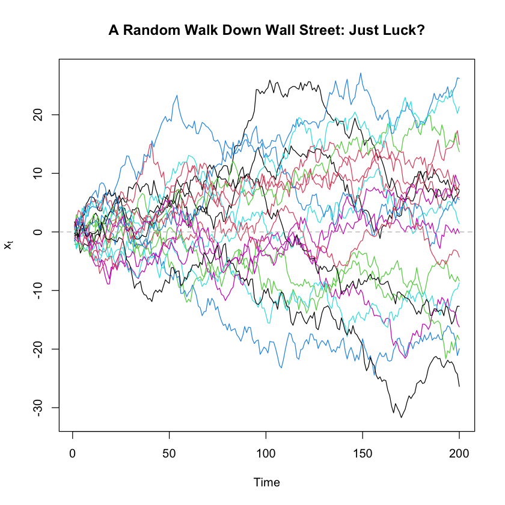

## Order of Integration

Unit roots raise a natural question: **how far is a series from stationarity?**

A time series $\{x_t\}$ is **integrated of order $d$**, written $x_t \sim I(d)$, if:

- $\Delta^d x_t$ is stationary, and
- $\Delta^{d-1} x_t$ is not,

where $\Delta = 1 - L$ is the difference operator.

### Interpretation:

- **$I(0)$**: stationary process
- **$I(1)$**: first differences are stationary
- **$I(d)$**: stationarity achieved after $d$ differences

## ARIMA Models

ARIMA stands for **Autoregressive Integrated Moving Average**.

If a process is integrated of order $d$,
$$x_t \sim I(d),$$
then
$$\Delta^d x_t \;\text{is stationary}.$$

An **ARIMA$(p,d,q)$** model assumes that the differenced series admits an ARMA representation:
$$\Phi(L)\,\Delta^d x_t = \Theta(L)\,\varepsilon_t.$$

- $d$: order of integration
- $p,q$: short-run dynamics of the stationary component

When $d=0$, ARIMA reduces to ARMA.

## Testing for Unit Roots

In ARIMA models, the order of integration $d$ captures the presence of unit roots in the data.

This requires assessing whether a time series contains zero, one, or multiple **unit roots**.

In its simplest form, consider the AR(1) model
$$x_t = \rho x_{t-1} + \varepsilon_t,
\qquad \varepsilon_t \sim \text{i.i.d.}(0,\sigma^2).$$

Testing for a unit root amounts to testing:
$$H_0:\ \rho = 1
\qquad \text{vs.} \qquad
H_1:\ \rho < 1.$$

## Unit Root Asymptotics

Consider the unit root model
$$x_t = x_{t-1} + \varepsilon_t,
\qquad \varepsilon_t \sim \text{i.i.d.}(0,\sigma^2).$$

Iterating forward,
$$x_t = x_0 + \sum_{j=1}^t \varepsilon_j.$$

A unit root process is a **partial sum of shocks**.

By CLT,

$$n^{-1/2} \sum_{i=1}^n \varepsilon_i
\;\xrightarrow{d}\;
N(0,\sigma^2).$$

This describes the behavior of the partial sum at a **fixed point in time**.

## Unit Root Asymptotics: Rescaling

Let
$$t = \lfloor rn \rfloor,
\qquad r \in [0,1].$$

Then,
$$\lfloor rn \rfloor^{-1/2}
\sum_{i=1}^{\lfloor rn \rfloor} \varepsilon_i
\;\xrightarrow{d}\;
N(0,\sigma^2).$$

Consider the scaled process
$$n^{-1/2} x_{\lfloor rn \rfloor}
=
n^{-1/2} x_0
+
\left( \frac{\lfloor rn \rfloor}{n} \right)^{1/2}
\lfloor rn \rfloor^{-1/2}
\sum_{i=1}^{\lfloor rn \rfloor} \varepsilon_i.$$

## Convergence to Brownian Motion

As $n \to \infty$, the initial condition vanishes:
$$n^{-1/2} x_0 \to 0.$$

Therefore,

$$n^{-1/2} x_{\lfloor rn \rfloor}
\;\xrightarrow{d}\;
r^{1/2} N(0,\sigma^2)
=
\sigma W(r),
\qquad r \in [0,1],$$

where $W(r)$ is a **Brownian motion**.

A unit root process converges to Brownian motion after appropriate scaling.

## Asymptotics of the OLS Estimator (Unit Root Case)

Recall that the OLS estimator in the AR(1) regression
$$y_t = \rho y_{t-1} + \varepsilon_t$$
satisfies
$$\hat\rho - \rho
=
\frac{\sum_{t=1}^n y_{t-1}\varepsilon_t}{\sum_{t=1}^n y_{t-1}^2}.$$

Under the unit root null hypothesis ($\rho = 1$), the following sample quantities satisfy:

$$\begin{aligned}
n^{-2}\sum_{t=1}^n y_{t-1}^2
&\;\xrightarrow{d}\;
\sigma^2 \int_0^1 W(r)^2\,dr, \\[6pt]
n^{-1}\sum_{t=1}^n y_{t-1}\varepsilon_t
&\;\xrightarrow{d}\;
\sigma^2 \int_0^1 W(r)\,dW(r),
\end{aligned}$$
where $W(r)$ is standard Brownian motion.

## Limit Distribution of $\hat\rho$ (Dickey–Fuller)

Under the null hypothesis $\rho = 1$,
$$n(\hat\rho - 1)
\;\xrightarrow{d}\;
\frac{\int_0^1 W(r)\,dW(r)}{\int_0^1 W(r)^2\,dr}.$$

The corresponding $t$ statistic is
$$t_n
=
\frac{\hat\rho - 1}{\hat\sigma_{\hat\rho}}
=
\frac{\hat\rho - 1}
{\hat\sigma\,(\sum_{t=1}^n y_{t-1}^2)^{-1/2}}
\;\xrightarrow{d}\;
\frac{\int_0^1 W(r)\,dW(r)}
{\left\{\int_0^1 W(r)^2\,dr\right\}^{1/2}}.$$

- $\hat\rho$ is **super-consistent**
- the $t$ statistic is **not asymptotically normal**
- its limiting distribution is known as the **Dickey–Fuller distribution**

## Dickey–Fuller Test

The unit root hypothesis is
$$H_0:\ \gamma = 0
\quad (\text{equivalently, } \rho = 1).$$

The DF regression can include deterministic terms:

| Specification | Regression |
| --- | --- |
| No deterministics | $\Delta y_t = \gamma y_{t-1} + \varepsilon_t$ |
| Intercept | $\Delta y_t = \alpha_0 + \gamma y_{t-1} + \varepsilon_t$ |
| Intercept + trend | $\Delta y_t = \alpha_0 + \alpha_1 t + \gamma y_{t-1} + \varepsilon_t$ |

The test statistic follows the **Dickey–Fuller distribution** (not standard normal) in all three cases, with different critical values.

## Augmented Dickey–Fuller

In practice, the AR(1) specification is too restrictive. For a general AR($p$) model, reparameterize in first differences:
$$\Delta y_t
=
\gamma y_{t-1}
+
\sum_{i=1}^{p-1} \beta_i \Delta y_{t-i}
+
\varepsilon_t,$$
where $\gamma = \sum_{i=1}^p a_i - 1$.

The lagged differences absorb higher-order dynamics; the unit root test remains $H_0: \gamma = 0$ with the same DF critical values.

## Determining the Order of Integration

ADF tests for a **single** unit root. But a series may be $I(0)$, $I(1)$, or $I(2)$.

**Dickey–Pantula (1987)** provides a size-controlled sequential procedure:

1. **Test $I(2)$ vs. $I(1)$**: regress $\Delta^2 y_t$ on $\Delta y_{t-1}$ (plus lags of $\Delta^2 y_t$). If the null is not rejected, conclude $I(2)$.
2. **Test $I(1)$ vs. $I(0)$**: if step 1 rejects, add $y_{t-2}$ to the regression and test its coefficient. Failure to reject $\Rightarrow I(1)$; rejection $\Rightarrow I(0)$.

The procedure tests from the **most differenced** hypothesis down, which controls size at each step. In practice, $d \in \{0,1,2\}$ covers nearly all cases.

## Example: ARIMA Modeling of U.S. Real GDP (FRED)

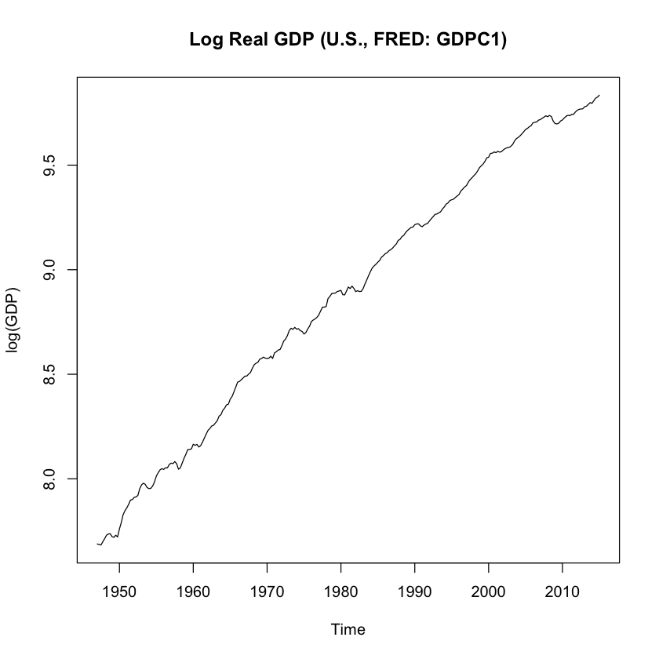

## First Differences of Log Real GDP

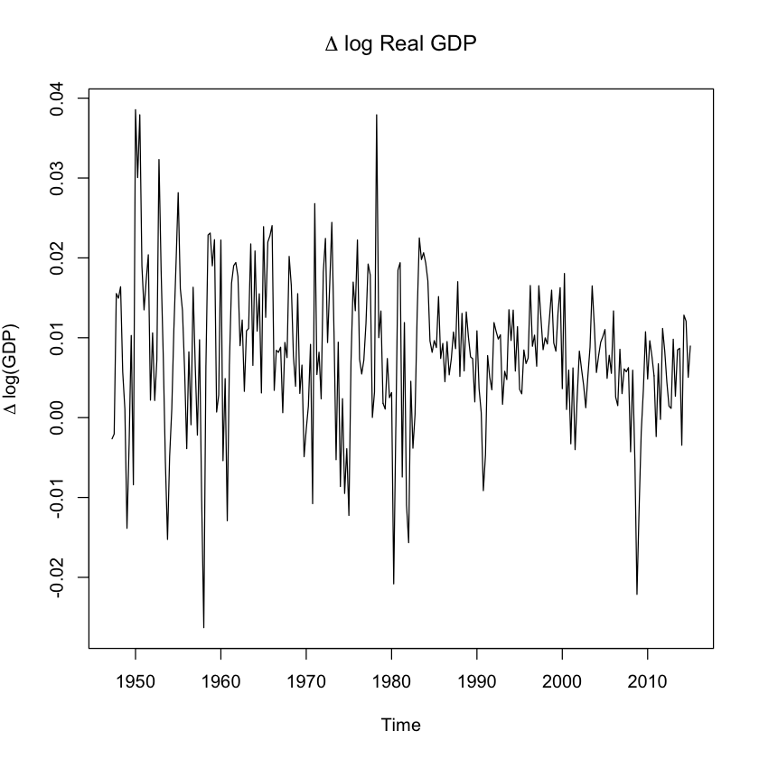

### Augmented Dickey–Fuller Test (U.S. Real GDP)

We test for a unit root using the **Dickey–Fuller test**, which is a **left-tailed test**.

**Null hypothesis (unit root):**
$$H_0:\ \rho = 1$$

**Alternative hypothesis (stationarity):**
$$H_1:\ \rho < 1$$

Rejection occurs when the test statistic is **more negative** than the Dickey–Fuller critical value.

```
ADF test (levels, with intercept)
 Test statistic (tau):  -2.025
 5% critical value:   -2.87

 ADF test (first differences)
 Test statistic (tau):  -7.63
 5% critical value:   -2.87
```

### ACF and PACF of $\Delta \log(\text{GDP})$

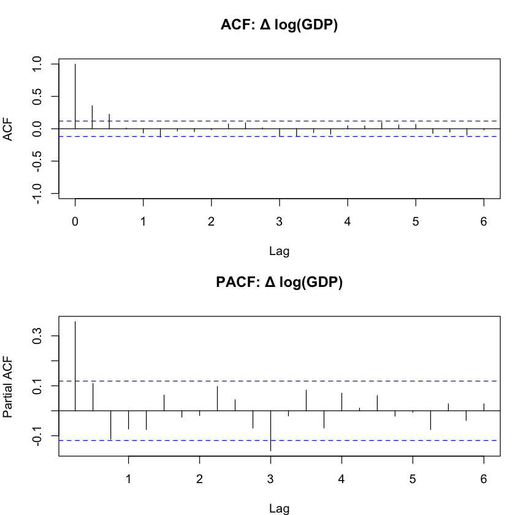

### Estimation: ARIMA(1,1,0)

The PACF cuts off after lag 1, suggesting an AR(1) for the differenced series, i.e., an **ARIMA(1,1,0)** model.

```r
fit_ar1 <- arima(gdp, order = c(1, 1, 0))
fit_ar1
```

```
Call:
arima(x = gdp, order = c(1, 1, 0))

Coefficients:
         ar1
      0.6173
s.e.  0.0475

sigma^2 estimated as 9.467e-05:  log likelihood = 873.87,  aic = -1743.73
```

### Estimation: ARIMA(0,1,2)

The ACF shows significant spikes at lags 1 and 2, which is also consistent with an **MA(2)** for the differenced series, i.e., an **ARIMA(0,1,2)** model.

```r
fit_ma2 <- arima(gdp, order = c(0, 1, 2))
fit_ma2
```

```
Call:
arima(x = gdp, order = c(0, 1, 2))

Coefficients:
         ma1     ma2
      0.4505  0.3367
s.e.  0.0624  0.0490

sigma^2 estimated as 0.0001001:  log likelihood = 866.3,  aic = -1726.6
```

## Model Selection: AIC and BIC

Given a set of candidate ARIMA$(p,d,q)$ models, we select using **information criteria**:

$$\text{AIC} = -2\log L(\hat\theta) + 2k,
\qquad
\text{BIC} = -2\log L(\hat\theta) + k\log T,$$
where $k$ is the number of estimated parameters (depends on $p$, $q$, and whether deterministic terms are included).

- AIC tends to select larger models (better for forecasting)
- BIC penalizes complexity more heavily (consistent for model selection)

### Model Comparison

```r
n <- length(dgdp)
aic <- c(fit_ar1$aic, fit_ma2$aic)
bic <- aic + (log(n) - 2) * c(length(fit_ar1$coef), length(fit_ma2$coef))
cat(sprintf("%-15s %10s %10s\n", "Model", "AIC", "BIC"))
cat(sprintf("%-15s %10.2f %10.2f\n", "ARIMA(1,1,0)", aic[1], bic[1]))
cat(sprintf("%-15s %10.2f %10.2f\n", "ARIMA(0,1,2)", aic[2], bic[2]))
```

```
Model                  AIC        BIC
ARIMA(1,1,0)      -1743.73   -1740.13
ARIMA(0,1,2)      -1726.60   -1719.39
```

Both criteria favor **ARIMA(1,1,0)**.

## Diagnostics

Model diagnostics assess whether the assumptions of the ARIMA model are plausibly satisfied by the data.

- the residuals are serially uncorrelated
- the residuals have constant variance
- the residuals have mean zero
- the residuals are normally distributed (not required, but good to have, esp. for MLE)

## Diagnostic Tools

- **Residual time series plot** → checks stability, outliers, variance changes
- **ACF of residuals** → checks remaining serial correlation
- **Ljung–Box test** → formal test of joint residual autocorrelation
  $$H_0:\ \rho_1 = \rho_2 = \cdots = \rho_h = 0,$$
  where $\rho_k$ denotes the autocorrelation of the model residuals at lag $k$.
- **Normal Q–Q plot** → assesses whether residuals are approximately normal → systematic deviations, especially in the tails, matter

Diagnostics do **not** test whether the model is “true” — they assess whether the model is **adequate**.

### Diagnostics: ARIMA(1,1,0) for U.S. Real GDP

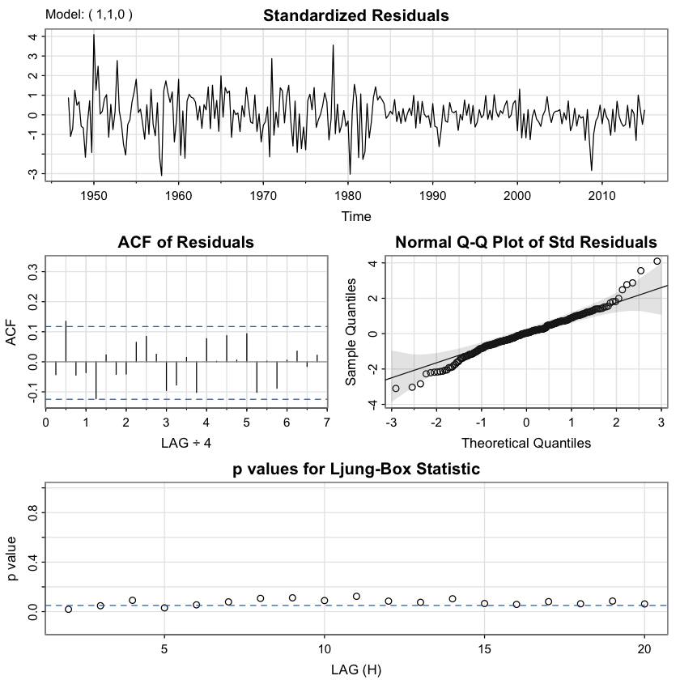

## Forecasting with ARIMA Models

Once an ARIMA model has been estimated and passes basic diagnostics, it can be used to generate **forecasts of future observations**.

Forecasting answers a different question than estimation:

- Estimation: *What statistical dependence structure fits the data?*
- Forecasting: *What does the fitted model imply about the future?*

Forecasts are **model-based extrapolations**, not statements of truth.

## A Key Assumption Behind Forecasting

All time series forecasting relies on a crucial assumption:

> **Past statistical regularities remain informative about the future.**

In ARIMA models, this means:

- the order of integration remains unchanged,
- the short-run dynamics are stable over the forecast horizon.

## What Does an ARIMA Forecast Deliver?

Given data observed up to time $t$ and estimated parameters $\hat\theta$, an ARIMA model implies a **model-based forecast distribution** for future observations:
$$y_{t+h}
\;\sim\;
\mathbb{P}_{\hat\theta}\!\left(\,\cdot \mid \mathscr{F}_t \right).$$

At time $t$, the information set $\mathscr{F}_t$ is observed. The fitted parameters $\hat\theta$ define the forecasting model. Randomness arises from future shocks implied by the model.

From this model-based forecast distribution, we obtain:

- a **point forecast**, defined as the model-based conditional mean
  $$\hat{y}_{t+h\mid t}
  \;\equiv\;
  \mathbb{E}_{\hat\theta}\!\left(y_{t+h}\mid \mathscr{F}_t\right),$$
- **prediction intervals**, constructed from quantiles of the model-based conditional distribution
  $$y_{t+h}\mid \mathscr{F}_t
  \;\sim\;
  \mathbb{P}_{\hat\theta}.$$

## Formal Prediction Intervals

Formally, a $(1-\alpha)$ prediction interval satisfies
$$\Pr_{\hat\theta}\!\left(
y_{t+h}\in[\ell_h,u_h]\mid \mathscr{F}_t
\right)=1-\alpha,$$
where $\ell_h$ and $u_h$ are the $\alpha/2$ and $1-\alpha/2$ quantiles of the model-based forecast distribution.

## Forecasting U.S. Real GDP

We continue with the ARIMA model fitted to log real GDP. Let
$$y_t = \log(\text{GDP}_t).$$

The fitted model is
$$\Delta y_t
=
\phi\,\Delta y_{t-1}
+
\varepsilon_t,
\qquad
\varepsilon_t \sim \text{i.i.d. }(0,\sigma^2).$$

Equivalently,
$$y_t
=
y_{t-1}
+
\phi\,\Delta y_{t-1}
+
\varepsilon_t.$$

## Point Forecast and One-Step-Ahead

### Point Forecast

The **point forecast** at horizon $h$ is defined as the conditional mean **under the fitted model**:

$$\hat y_{t+h\mid t}
\;\equiv\;
\mathbb E_{\hat\theta}\!\left(
y_{t+h}
\mid
\mathscr{F}_t
\right),$$
where $\hat\theta=(\hat\phi,\hat\sigma^2)$ denotes the estimated model parameters.

**One-Step-Ahead Forecast**

From the model equation,
$$y_{t+1}
=
y_{t}
+
\phi\,\Delta y_t
+
\varepsilon_{t+1},$$
taking conditional expectations given $\mathscr{F}_t$ and $\hat\theta$, and using $\mathbb E_{\hat\theta}(\varepsilon_{t+1}\mid\mathscr{F}_t)=0$, we obtain the one-step-ahead point forecast
$$\hat y_{t+1\mid t}
=
y_t
+
\hat\phi\,\Delta y_t.$$

### Forecast Uncertainty

Point forecasts summarize the **center** of the forecast distribution, but forecasting also requires quantifying **uncertainty**.

Consider the **fitted** ARIMA$(1,1,0)$ model
$$\Delta y_t
=
\hat\phi\,\Delta y_{t-1}
+
\varepsilon_t,
\qquad
\varepsilon_t \sim \text{i.i.d. }(0,\hat\sigma^2).$$

At time $t$, the information set $\mathscr F_t$ and the estimated parameters $\hat\theta=(\hat\phi,\hat\sigma^2)$ are treated as fixed.

Under this conditioning, randomness arises **only from future innovations**
$$\varepsilon_{t+1}, \varepsilon_{t+2}, \ldots$$

## One-Step-Ahead Forecast Error

From the fitted model,
$$y_{t+1}
=
y_t
+
\hat\phi\,\Delta y_t
+
\varepsilon_{t+1},$$
taking conditional expectations yields the point forecast
$$\hat y_{t+1\mid t}
=
y_t
+
\hat\phi\,\Delta y_t.$$

Therefore, the one-step-ahead forecast error is
$$y_{t+1} - \hat y_{t+1\mid t}
=
\varepsilon_{t+1}.$$

## Multi-Step Forecast Errors

**Two-step-ahead forecast error**

Iterating the model forward one more step, the two-step-ahead forecast error satisfies
$$y_{t+2}-\hat y_{t+2\mid t}
=
(1+\hat\phi)\,\varepsilon_{t+1}
+
\varepsilon_{t+2}.$$

This illustrates how forecast uncertainty **accumulates and propagates** with the forecast horizon.

### Prediction Intervals

Under the fitted ARIMA$(1,1,0)$ model, forecast errors are **linear combinations** of future innovations:
$$y_{t+h}-\hat y_{t+h\mid t}
=
\sum_{j=1}^h w_{h,j}\,\varepsilon_{t+j},$$
where the weights $w_{h,j}$ depend on $\hat\phi$.

Since the fitted model assumes
$$\varepsilon_{t+j} \sim \text{i.i.d. }(0,\hat\sigma^2),$$
the model-based forecast distribution of $y_{t+h}$ is centered at $\hat y_{t+h\mid t}$, with variance increasing in the forecast horizon $h$.

## Gaussian Prediction Intervals

Under the maintained **Gaussian assumption**, the model-based forecast error is normally distributed:
$$y_{t+h} - \hat y_{t+h\mid t}
\;\sim\;
N\!\left(
0,\;
\mathrm{Var}_{\hat\theta}\!\left(y_{t+h}-\hat y_{t+h\mid t}\right)
\right).$$

Therefore, a $(1-\alpha)$ **model-based prediction interval** for $y_{t+h}$ is
$$\hat y_{t+h\mid t}
\;\pm\;
z_{1-\alpha/2}
\sqrt{
\mathrm{Var}_{\hat\theta}\!\left(y_{t+h}-\hat y_{t+h\mid t}\right)
},$$
where $z_{1-\alpha/2}$ is the $(1-\alpha/2)$ quantile of the standard normal distribution.

### Out-of-Sample Forecast

```
Out-of-sample evaluation (h = 10 quarters)
RMSE: 0.0189
MAE:  0.0142
```

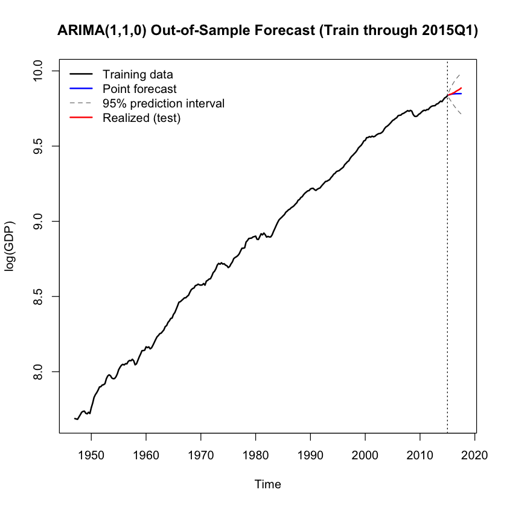

## Forecast Evaluation

Forecasting ultimately concerns **realized outcomes**, not models.

A forecast made at time $t$,
$$\hat y_{t+h\mid t},$$
is evaluated against what actually occurs,
$$y_{t+h}.$$

The **realized forecast error** is
$$e_{t+h}
=
y_{t+h}
-
\hat y_{t+h\mid t}.$$

This realized error combines **all sources of forecast uncertainty**:

- future shocks,
- parameter estimation error,
- model misspecification.

## Expected Squared Forecast Error

A single realized forecast error $e_{t+h}$ is informative, but forecast evaluation requires **averaging over repeated realizations**.

The standard criterion is the **mean squared forecast error (MSFE)**:
$$\mathrm{MSFE}(h)
=
\mathbb{E}\!\left[
\left(
y_{t+h}
-
\hat y_{t+h\mid t}
\right)^2
\right],$$
where the expectation is taken unconditionally under the true data-generating process.

## MSFE Decomposition

To understand the sources of forecast error, write
$$y_{t+h}
-
\hat y_{t+h\mid t}
=
\underbrace{
\bigl(y_{t+h}-y_{t+h}^\ast\bigr)
}_{\text{unpredictable shocks}}
+
\underbrace{
\bigl(y_{t+h}^\ast-\hat y_{t+h\mid t}\bigr)
}_{\text{forecast construction error}},$$
where
$$y_{t+h}^\ast
\equiv
\mathbb{E}\!\left(y_{t+h}\mid \mathscr F_t\right)$$
denotes the **ideal conditional forecast** under the true data-generating process.

Squaring and taking expectations yields the familiar decomposition:
$$\mathrm{MSFE}(h)
=
\underbrace{
\mathbb{E}\!\left[
\left(y_{t+h}-y_{t+h}^\ast\right)^2
\right]
}_{\text{irreducible uncertainty}}
+
\underbrace{
\mathbb{E}\!\left[
\left(y_{t+h}^\ast-\hat y_{t+h\mid t}\right)^2
\right]
}_{\text{bias and estimation error}}.$$

## Bias–Variance Decomposition (Forecasting)

The second term in the MSFE decomposition,
$$\mathbb{E}\!\left[
\left(y_{t+h}^\ast-\hat y_{t+h\mid t}\right)^2
\right],$$
captures **systematic forecast error**.

To obtain a bias–variance decomposition, we work **conditionally on the information set** $\mathscr F_t$.

$$\mathbb E\!\left[
(y^*_{t+h}-\hat y_{t+h\mid t})^2
\mid \mathscr F_t
\right]
=
\underbrace{
\left(
\mathbb E[\hat y_{t+h\mid t}\mid \mathscr F_t]-y^*_{t+h}
\right)^2
}_{\text{forecast bias}^2}
+
\underbrace{
\mathrm{Var}(\hat y_{t+h\mid t}\mid \mathscr F_t)
}_{\text{forecast variance}}.$$

## Bias–Variance Tradeoff

**Interpretation**

- **Bias** reflects systematic misspecification relative to the true conditional mean
- **Variance** reflects sensitivity of the forecast to sampling and parameter estimation

This decomposition highlights a fundamental **bias–variance tradeoff** in forecasting: simpler models may be biased but stable, while flexible models may reduce bias at the cost of higher variance.

Averaging over forecasting situations (i.e. over $\mathscr F_t$) yields the unconditional contribution to the MSFE:
$$\mathbb{E}\!\left[
(y^*_{t+h}-\hat y_{t+h\mid t})^2
\right]
=
\mathbb{E}\!\left[
\left(
\mathbb E[\hat y_{t+h\mid t}\mid \mathscr F_t]-y^*_{t+h}
\right)^2
\right]
+
\mathbb{E}\!\left[
\mathrm{Var}(\hat y_{t+h\mid t}\mid \mathscr F_t)
\right].$$

## Empirical Forecast Evaluation

The MSFE is a **population object**:
$$\mathrm{MSFE}(h)
=
\mathbb{E}\!\left[
\left(
y_{t+h}
-
\hat y_{t+h\mid t}
\right)^2
\right].$$

In practice, we observe **one realized path**. Expectations are therefore replaced by out-of-sample averages.

This leads to the **root mean squared forecast error (RMSE)**:
$$\widehat{\mathrm{RMSE}}(h)
=
\sqrt{
\frac{1}{T}
\sum_{t=1}^T
\left(
y_{t+h}
-
\hat y_{t+h\mid t}
\right)^2
}.$$

## Mean Absolute Error

Another commonly used criterion is the **mean absolute error (MAE)**:
$$\widehat{\mathrm{MAE}}(h)
=
\frac{1}{T}
\sum_{t=1}^T
\left|
y_{t+h}
-
\hat y_{t+h\mid t}
\right|.$$

MAE penalizes errors **linearly**, rather than quadratically.

As a result:

- RMSE is more sensitive to large mistakes,
- MAE is more robust to outliers.

## Remark on Forecast Evaluation

The MSFE and RMSE are defined in terms of **forecast errors**, not the level of the time series.

For forecast evaluation to be meaningful, we implicitly require that:

- the distribution of forecast errors is **stable over time**, and
- sample averages of forecast errors converge to population averages.

### What This Means in Practice

- The level series $y_t$ itself **need not be stationary** (e.g. $y_t$ may be $I(1)$ or $I(d)$).
- What matters is that the **forecast error process**
  $$e_{t+h} = y_{t+h} - \hat y_{t+h\mid t}$$
  is stationary and ergodic.

This is exactly what ARIMA models are designed to deliver.

## Looking Ahead

ARIMA models handle **univariate** nonstationary series by differencing.

What they leave out:

- **Explanatory variables** — ARIMA uses only the history of the series itself. What if other variables help predict it? *(Unit 5: Regression with Time Series Data)*
- **Multiple nonstationary series** — regressing one $I(1)$ series on another can produce spurious results. But if the series share a common stochastic trend, they may be cointegrated. *(Unit 6: Cointegration)*